# R: Multidimensional discrete item response theory

| mdirt {mirt} | R Documentation |
| --- | --- |

## Multidimensional discrete item response theory

### Description

`mdirt` fits a variety of item response models with discrete latent variables. These include, but are not limited to, latent class analysis, multidimensional latent class models, multidimensional discrete latent class models, DINA/DINO models, grade of measurement models, C-RUM, and so on. If response models are not defined explicitly then customized models can defined using the `createItem` function.

### Usage

```r
mdirt(
  data,
  model,
  customTheta = NULL,
  structure = NULL,
  item.Q = NULL,
  nruns = 1,
  method = "EM",
  covdata = NULL,
  formula = NULL,
  itemtype = "lca",
  optimizer = "nlminb",
  return_max = TRUE,
  group = NULL,
  GenRandomPars = FALSE,
  verbose = TRUE,
  pars = NULL,
  technical = list(),
  ...
)
```

### Arguments

| `data` | a `matrix` or `data.frame` that consists of numerically ordered data, organized in the form of integers, with missing data coded as `NA` |
| --- | --- |
| `model` | number of mutually exclusive classes to fit, or alternatively a more specific `mirt.model` definition (which reflects the so-called Q-matrix). Note that when using a `mirt.model`, the order with which… |
| `customTheta` | input passed to `technical = list(customTheta = ...)`, but is included directly in this function for convenience. This input is most interesting for discrete latent models because it allows customized… |
| `structure` | an R formula allowing the profile probability patterns (i.e., the structural component of the model) to be fitted according to a log-linear model. When `NULL`, all profile probabilities (except one) w… |
| `item.Q` | a list of item-level Q-matrices indicating how the respective categories should be modeled by the underlying attributes. Each matrix must represent a `K_i \times A` matrix, where `K_i` represents the … |
| `nruns` | a numeric value indicating how many times the model should be fit to the data when using random starting values. If greater than 1, `GenRandomPars` is set to true by default |
| `method` | estimation method. Can be 'EM' or 'BL' (see `mirt` for more details) |
| `covdata` | a data.frame of data used for latent regression models |
| `formula` | an R formula (or list of formulas) indicating how the latent traits can be regressed using external covariates in `covdata`. If a named list of formulas is supplied (where the names correspond to the … |
| `itemtype` | a vector indicating the itemtype associated with each item. For discrete models this is limited to only 'lca' or items defined using a `createItem` definition |
| `optimizer` | optimizer used for the M-step, set to `'nlminb'` by default. See `mirt` for more details |
| `return_max` | logical; when `nruns > 1`, return the model that has the most optimal maximum likelihood criteria? If FALSE, returns a list of all the estimated objects |
| `group` | a factor variable indicating group membership used for multiple group analyses |
| `GenRandomPars` | logical; use random starting values |
| `verbose` | logical; turn on messages to the R console |
| `pars` | used for modifying starting values; see `mirt` for details |
| `technical` | list of lower-level inputs. See `mirt` for details |
| `...` | additional arguments to be passed to the estimation engine. See `mirt` for more details and examples |

### Details

Posterior classification accuracy for each response pattern may be obtained via the `fscores` function. The `summary()` function will display the category probability values given the class membership, which can also be displayed graphically with `plot()`, while `coef()` displays the raw coefficient values (and their standard errors, if estimated). Finally, `anova()` is used to compare nested models, while `M2` and `itemfit` may be used for model fitting purposes.

### 'lca' model definition

The latent class IRT model with two latent classes has the form

```
P(x = k|\theta_1, \theta_2, a1, a2) = \frac{exp(a1 \theta_1 + a2 \theta_2)}{
  \sum_j^K exp(a1 \theta_1 + a2 \theta_2)}
```

where the `\theta` values generally take on discrete points (such as 0 or 1). For proper identification, the first category slope parameters (`a1` and `a2`) are never freely estimated. Alternatively, supplying a different grid of `\theta` values will allow the estimation of similar models (multidimensional discrete models, grade of membership, etc.). See the examples below.

When the `item.Q` for is utilized, the above equation can be understood as

```
P(x = k|\theta_1, \theta_2, a1, a2) = \frac{exp(a1 \theta_1 Q_{j1} + a2 \theta_2 Q_{j2})}{
  \sum_j^K exp(a1 \theta_1 Q_{j1} + a2 \theta_2 Q_{j2})}
```

where by construction `Q` is a `K_i \times A` matrix indicating whether the category should be modeled according to the latent class structure. For the standard latent class model, the Q-matrix has as many rows as categories, as many columns as the number of classes/attributes modeled, and consist of 0's in the first row and 1's elsewhere. This of course can be over-written by passing an alternative `item.Q` definition for each respective item.

### Author(s)

Phil Chalmers rphilip.chalmers@gmail.com

### References

Chalmers, R., P. (2012). mirt: A Multidimensional Item Response Theory Package for the R Environment. *Journal of Statistical Software, 48*(6), 1-29.

### See Also

`thetaComb`, `fscores`, `mirt.model`, `M2`, `itemfit`, `boot.mirt`, `mirtCluster`, `wald`, `coef-method`, `summary-method`, `anova-method`, `residuals-method`

### Examples

```r
# LSAT6 dataset
dat <- expand.table(LSAT6)

# fit with 2-3 latent classes
(mod2 <- mdirt(dat, 2))
```

```
##
## Call:
## mdirt(data = dat, model = 2)
##
## Latent class model with 2 classes and 2 profiles.
## Converged within 1e-04 tolerance after 363 EM iterations.
## mirt version: 1.43
## M-step optimizer: nlminb
## EM acceleration: Ramsay
## Latent density type: discrete
##
## Log-likelihood = -2467.408
## Estimated parameters: 11
## AIC = 4956.816
## BIC = 5010.802; SABIC = 4975.865
## G2 (20) = 22.74, p = 0.3018, RMSEA = 0.012
```

```r
## No test:
(mod3 <- mdirt(dat, 3))
```

```
##
## Call:
## mdirt(data = dat, model = 3)
##
## Latent class model with 3 classes and 3 profiles.
## FAILED TO CONVERGE within 1e-04 tolerance after 500 EM iterations.
## mirt version: 1.43
## M-step optimizer: nlminb
## EM acceleration: Ramsay
## Latent density type: discrete
##
## Log-likelihood = -2465.25
## Estimated parameters: 17
## AIC = 4964.5
## BIC = 5047.932; SABIC = 4993.939
## G2 (14) = 18.42, p = 0.1882, RMSEA = 0.018
```

```r
summary(mod2)
```

```
## $Item_1
##        category_1 category_2
## P[1 0]      0.156      0.844
## P[0 1]      0.037      0.963
##
## $Item_2
##        category_1 category_2
## P[1 0]      0.485      0.515
## P[0 1]      0.196      0.804
##
## $Item_3
##        category_1 category_2
## P[1 0]      0.713      0.287
## P[0 1]      0.317      0.683
##
## $Item_4
##        category_1 category_2
## P[1 0]      0.401      0.599
## P[0 1]      0.157      0.843
##
## $Item_5
##        category_1 category_2
## P[1 0]      0.232      0.768
## P[0 1]      0.080      0.920
##
## $Class.Probability
##           F1 F2  prob
## Profile_1  1  0 0.329
## Profile_2  0  1 0.671
```

```r
residuals(mod2)
```

```
##        Item_1 Item_2 Item_3 Item_4 Item_5
## Item_1     NA  0.010  0.020 -0.011 -0.018
## Item_2  0.109     NA  0.003 -0.018  0.022
## Item_3  0.412  0.009     NA  0.008 -0.026
## Item_4  0.132  0.313  0.060     NA  0.040
## Item_5  0.331  0.487  0.680  1.566     NA
```

```r
residuals(mod2, type = 'exp')
```

```
##    Item_1 Item_2 Item_3 Item_4 Item_5 freq     exp std.res
## 1       0      0      0      0      0    3   1.662   1.038
## 2       0      0      0      0      1    6   5.673   0.137
## 3       0      0      0      1      0    2   2.556  -0.348
## 4       0      0      0      1      1   11   9.333   0.546
## 5       0      0      1      0      0    1   0.702   0.356
## 6       0      0      1      0      1    1   2.670  -1.022
## 7       0      0      1      1      0    3   1.211   1.626
## 8       0      0      1      1      1    4   5.855  -0.767
## 9       0      1      0      0      0    1   1.826  -0.611
## 10      0      1      0      0      1    8   6.708   0.499
## 11      0      1      0      1      1   16  13.561   0.662
## 12      0      1      1      0      1    3   4.297  -0.625
## 13      0      1      1      1      0    2   1.972   0.020
## 14      0      1      1      1      1   15  14.075   0.247
```

[output cut: 16 more lines]

```r
anova(mod2, mod3)
```

```
##           AIC    SABIC       HQ      BIC    logLik    X2 df     p
## mod2 4956.816 4975.865 4977.335 5010.802 -2467.408
## mod3 4964.500 4993.939 4996.210 5047.932 -2465.250 4.317  6 0.634
```

```r
M2(mod2)
```

```
##             M2 df         p      RMSEA RMSEA_5   RMSEA_95      SRMSR      TLI
## stats 4.603509  4 0.3304498 0.01228935       0 0.05069941 0.02122285 0.973442
##             CFI
## stats 0.9893768
```

```r
itemfit(mod2)
```

```
##     item  S_X2 df.S_X2 RMSEA.S_X2 p.S_X2
## 1 Item_1 0.433       2          0  0.805
## 2 Item_2 1.702       2          0  0.427
## 3 Item_3 0.747       1          0  0.387
## 4 Item_4 0.184       2          0  0.912
## 5 Item_5 0.145       2          0  0.930
```

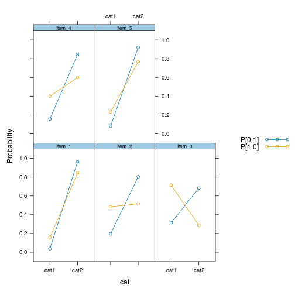

```r
# generate classification plots
plot(mod2)
```

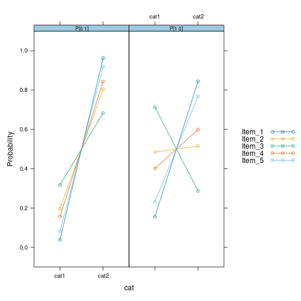

```r
plot(mod2, facet_items = FALSE)
```

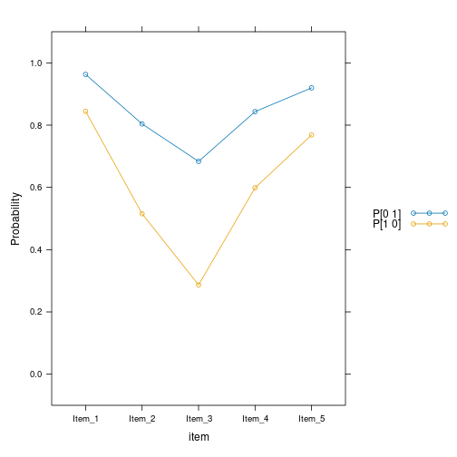

```r
plot(mod2, profile = TRUE)
```

```r
# available for polytomous data
mod <- mdirt(Science, 2)
summary(mod)
```

```
## $Comfort
##        category_1 category_2 category_3 category_4
## P[1 0]      0.018      0.095      0.766      0.121
## P[0 1]      0.000      0.051      0.474      0.475
##
## $Work
##        category_1 category_2 category_3 category_4
## P[1 0]      0.115      0.329      0.520      0.036
## P[0 1]      0.013      0.065      0.537      0.385
##
## $Future
##        category_1 category_2 category_3 category_4
## P[1 0]      0.051      0.262      0.619      0.068
## P[0 1]      0.001      0.000      0.340      0.659
##
## $Benefit
##        category_1 category_2 category_3 category_4
## P[1 0]      0.072      0.323      0.516      0.089
## P[0 1]      0.011      0.097      0.437      0.455
##
## $Class.Probability
##           F1 F2  prob
## Profile_1  1  0 0.701
## Profile_2  0  1 0.299
```

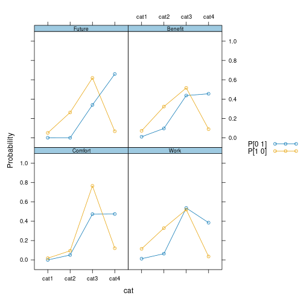

```r
plot(mod)
```

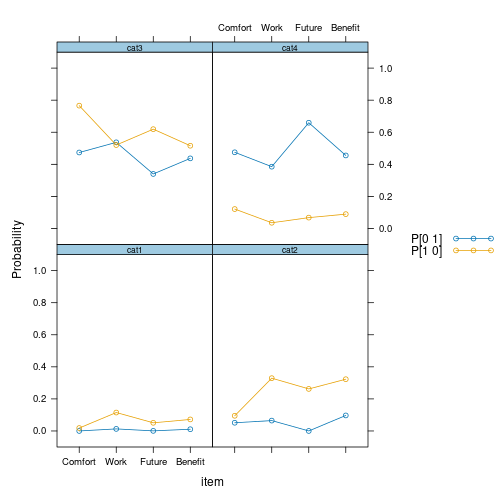

```r
plot(mod, profile=TRUE)
```

```r
# classification based on response patterns
fscores(mod2, full.scores = FALSE)
```

```
##       Item_1 Item_2 Item_3 Item_4 Item_5    Class_1    Class_2
##  [1,]      0      0      0      0      0 0.98832539 0.01167461
##  [2,]      0      0      0      0      1 0.96080421 0.03919579
##  [3,]      0      0      0      1      0 0.95911420 0.04088580
##  [4,]      0      0      0      1      1 0.87167305 0.12832695
##  [5,]      0      0      1      0      0 0.94030147 0.05969853
##  [6,]      0      0      1      0      1 0.82016986 0.17983014
##  [7,]      0      0      1      1      0 0.81359256 0.18640744
##  [8,]      0      0      1      1      1 0.55826672 0.44173328
##  [9,]      0      1      0      0      0 0.95646627 0.04353373
## [10,]      0      1      0      0      1 0.86416411 0.13583589
## [11,]      0      1      0      1      1 0.63805843 0.36194157
## [12,]      0      1      1      0      1 0.54205358 0.45794642
## [13,]      0      1      1      1      0 0.53111944 0.46888056
## [14,]      0      1      1      1      1 0.24698538 0.75301462
```

[output cut: 16 more lines]

```r
# classify individuals either with the largest posterior probability.....
fs <- fscores(mod2)
head(fs)
```

```
##     Class_1    Class_2
## 1 0.9883254 0.01167461
## 2 0.9883254 0.01167461
## 3 0.9883254 0.01167461
## 4 0.9608042 0.03919579
## 5 0.9608042 0.03919579
## 6 0.9608042 0.03919579
```

```r
classes <- 1:2
class_max <- classes[apply(apply(fs, 1, max) == fs, 1, which)]
table(class_max)
```

```
## class_max
##   1   2
## 291 709
```

```r
# ... or by probability sampling (i.e., plausible value draws)
class_prob <- apply(fs, 1, function(x) sample(1:2, 1, prob=x))
table(class_prob)
```

```
## class_prob
##   1   2
## 329 671
```

```r
# plausible value imputations for stochastic classification in both classes
pvs <- fscores(mod2, plausible.draws=10)
tabs <- lapply(pvs, function(x) apply(x, 2, table))
tabs[[1]]
```

```
##   [,1] [,2]
## 0  673  322
## 1  327  678
```

```r
# fit with random starting points (run in parallel to save time)
if(interactive()) mirtCluster()
mod <- mdirt(dat, 2, nruns=10)
```

```
## Model log-likelihoods:
##  [1] -2467.408 -2467.408 -2467.408 -2467.408 -2467.408 -2467.408 -2467.408
##  [8] -2467.408 -2467.408 -2467.407
```

```r
#--------------------------
# Grade of measurement model

# define a custom Theta grid for including a 'fuzzy' class membership
(Theta <- matrix(c(1, 0, .5, .5, 0, 1), nrow=3 , ncol=2, byrow=TRUE))
```

```
##      [,1] [,2]
## [1,]  1.0  0.0
## [2,]  0.5  0.5
## [3,]  0.0  1.0
```

```r
(mod_gom <- mdirt(dat, 2, customTheta = Theta))
```

```
##
## Call:
## mdirt(data = dat, model = 2, customTheta = Theta)
##
## Latent class model with 2 classes and 3 profiles.
## FAILED TO CONVERGE within 1e-04 tolerance after 500 EM iterations.
## mirt version: 1.43
## M-step optimizer: nlminb
## EM acceleration: Ramsay
## Latent density type: discrete
##
## Log-likelihood = -2466.602
## Estimated parameters: 12
## AIC = 4957.205
## BIC = 5016.098; SABIC = 4977.985
## G2 (19) = 21.13, p = 0.3298, RMSEA = 0.011
```

```r
summary(mod_gom)
```

```
## $Item_1
##            category_1 category_2
## P[1 0]          0.322      0.678
## P[0.5 0.5]      0.102      0.898
## P[0 1]          0.026      0.974
##
## $Item_2
##            category_1 category_2
## P[1 0]          0.692      0.308
## P[0.5 0.5]      0.386      0.614
## P[0 1]          0.150      0.850
##
## $Item_3
##            category_1 category_2
## P[1 0]          0.866      0.134
## P[0.5 0.5]      0.592      0.408
## P[0 1]          0.247      0.753
##
## $Item_4
##            category_1 category_2
## P[1 0]          0.603      0.397
## P[0.5 0.5]      0.313      0.687
## P[0 1]          0.120      0.880
##
## $Item_5
##            category_1 category_2
## P[1 0]          0.398      0.602
## P[0.5 0.5]      0.171      0.829
## P[0 1]          0.061      0.939
##
## $Class.Probability
##            F1  F2  prob
## Profile_1 1.0 0.0 0.037
## Profile_2 0.5 0.5 0.513
## Profile_3 0.0 1.0 0.450
```

```r
#-----------------
# Multidimensional discrete latent class model

dat <- key2binary(SAT12,
     key = c(1,4,5,2,3,1,2,1,3,1,2,4,2,1,5,3,4,4,1,4,3,3,4,1,3,5,1,3,1,5,4,5))

# define Theta grid for three latent classes
(Theta <- thetaComb(0:1, 3))
```

```
##      [,1] [,2] [,3]
## [1,]    0    0    0
## [2,]    1    0    0
## [3,]    0    1    0
## [4,]    1    1    0
## [5,]    0    0    1
## [6,]    1    0    1
## [7,]    0    1    1
## [8,]    1    1    1
```

```r
(mod_discrete <- mdirt(dat, 3, customTheta = Theta))
```

```
##
## Call:
## mdirt(data = dat, model = 3, customTheta = Theta)
##
## Latent class model with 3 classes and 8 profiles.
## Converged within 1e-04 tolerance after 139 EM iterations.
## mirt version: 1.43
## M-step optimizer: nlminb
## EM acceleration: Ramsay
## Latent density type: discrete
##
## Log-likelihood = -9429.721
## Estimated parameters: 103
## AIC = 19065.44
## BIC = 19518.33; SABIC = 19191.33
## G2 (4294967192) = 11189.72, p = 1, RMSEA = 0
```

```r
summary(mod_discrete)
```

```
## $Item.1
##          category_1 category_2
## P[0 0 0]      0.500      0.500
## P[1 0 0]      0.868      0.132
## P[0 1 0]      0.460      0.540
## P[1 1 0]      0.849      0.151
## P[0 0 1]      0.341      0.659
## P[1 0 1]      0.773      0.227
## P[0 1 1]      0.306      0.694
## P[1 1 1]      0.744      0.256
##
## $Item.2
##          category_1 category_2
## P[0 0 0]      0.500      0.500
## P[1 0 0]      0.945      0.055
## P[0 1 0]      0.165      0.835
## P[1 1 0]      0.774      0.226
## P[0 0 1]      0.073      0.927
## P[1 0 1]      0.575      0.425
## P[0 1 1]      0.015      0.985
## P[1 1 1]      0.211      0.789
##
## $Item.3
##          category_1 category_2
## P[0 0 0]      0.500      0.500
## P[1 0 0]      0.929      0.071
## P[0 1 0]      0.337      0.663
## P[1 1 0]      0.870      0.130
## P[0 0 1]      0.271      0.729
## P[1 0 1]      0.830      0.170
## P[0 1 1]      0.159      0.841
## P[1 1 1]      0.712      0.288
##
## $Item.4
##          category_1 category_2
## P[0 0 0]      0.500      0.500
## P[1 0 0]      0.844      0.156
## P[0 1 0]      0.223      0.777
## P[1 1 0]      0.609      0.391
## P[0 0 1]      0.428      0.572
```

[output cut: 307 more lines]

```
## P[0 0 1]      0.702      0.298
## P[1 0 1]      0.863      0.137
## P[0 1 1]      0.755      0.245
## P[1 1 1]      0.892      0.108
##
## $Class.Probability
##           F1 F2 F3  prob
## Profile_1  0  0  0 0.000
## Profile_2  1  0  0 0.004
## Profile_3  0  1  0 0.002
## Profile_4  1  1  0 0.194
## Profile_5  0  0  1 0.084
## Profile_6  1  0  1 0.368
## Profile_7  0  1  1 0.058
## Profile_8  1  1  1 0.290
```

```r
# Located latent class model
model <- mirt.model('C1 = 1-32
                     C2 = 1-32
                     C3 = 1-32
                     CONSTRAIN = (1-32, a1), (1-32, a2), (1-32, a3)')
(mod_located <- mdirt(dat, model, customTheta = diag(3)))
```

[output not shown]

```r
summary(mod_located)
```

```
## $Item.1
##          category_1 category_2
## P[1 0 0]      0.578      0.422
## P[0 1 0]      0.410      0.590
## P[0 0 1]      0.190      0.810
##
## $Item.2
##          category_1 category_2
## P[1 0 0]      0.578      0.422
## P[0 1 0]      0.410      0.590
## P[0 0 1]      0.190      0.810
##
## $Item.3
##          category_1 category_2
## P[1 0 0]      0.578      0.422
## P[0 1 0]      0.410      0.590
## P[0 0 1]      0.190      0.810
##
## $Item.4
##          category_1 category_2
## P[1 0 0]      0.578      0.422
## P[0 1 0]      0.410      0.590
## P[0 0 1]      0.190      0.810
##
## $Item.5
##          category_1 category_2
## P[1 0 0]      0.578      0.422
## P[0 1 0]      0.410      0.590
## P[0 0 1]      0.190      0.810
##
## $Item.6
##          category_1 category_2
## P[1 0 0]      0.578      0.422
## P[0 1 0]      0.410      0.590
## P[0 0 1]      0.190      0.810
##
## $Item.7
##          category_1 category_2
## P[1 0 0]      0.578      0.422
## P[0 1 0]      0.410      0.590
```

[output cut: 142 more lines]

```
## P[1 0 0]      0.578      0.422
## P[0 1 0]      0.410      0.590
## P[0 0 1]      0.190      0.810
##
## $Item.32
##          category_1 category_2
## P[1 0 0]      0.578      0.422
## P[0 1 0]      0.410      0.590
## P[0 0 1]      0.190      0.810
##
## $Class.Probability
##           C1 C2 C3  prob
## Profile_1  1  0  0 0.339
## Profile_2  0  1  0 0.497
## Profile_3  0  0  1 0.164
```

```r
#-----------------
### DINA model example
# generate some suitable data for a two dimensional DINA application
#     (first columns are intercepts)
set.seed(1)
Theta <- expand.table(matrix(c(1,0,0,0,
                               1,1,0,0,
                               1,0,1,0,
                               1,1,1,1), 4, 4, byrow=TRUE),
                      freq = c(200,200,100,500))
a <- matrix(c(rnorm(15, -1.5, .5), rlnorm(5, .2, .3), numeric(15), rlnorm(5, .2, .3),
              numeric(15), rlnorm(5, .2, .3)), 15, 4)

guess <- plogis(a[11:15,1]) # population guess
slip <- 1 - plogis(rowSums(a[11:15,])) # population slip

dat <- simdata(a, Theta=Theta, itemtype = 'lca')

# first column is the intercept, 2nd and 3rd are attributes
theta <- cbind(1, thetaComb(0:1, 2))
theta <- cbind(theta, theta[,2] * theta[,3]) #DINA interaction of main attributes
model <- mirt.model('Intercept = 1-15
                     A1 = 1-5
                     A2 = 6-10
                     A1A2 = 11-15')

# last 5 items are DINA (first 10 are unidimensional C-RUMs)
DINA <- mdirt(dat, model, customTheta = theta)
coef(DINA, simplify=TRUE)
```

```
## $items
##             a1    a2    a3    a4
## Item_1  -1.630 1.115 0.000 0.000
## Item_2  -1.052 0.841 0.000 0.000
## Item_3  -1.582 1.271 0.000 0.000
## Item_4  -0.388 1.229 0.000 0.000
## Item_5  -1.054 1.340 0.000 0.000
## Item_6  -2.569 0.000 2.500 0.000
## Item_7  -1.100 0.000 1.435 0.000
## Item_8  -1.103 0.000 1.054 0.000
## Item_9  -1.474 0.000 1.041 0.000
## Item_10 -1.620 0.000 1.359 0.000
## Item_11 -0.542 0.000 0.000 0.997
## Item_12 -1.584 0.000 0.000 1.609
## Item_13 -1.881 0.000 0.000 0.934
## Item_14 -2.663 0.000 0.000 0.912
## Item_15 -0.813 0.000 0.000 1.005
##
## $group.intercepts
##         c1    c2     c3
## par -0.545 -1.53 -1.468
```

```r
summary(DINA)
```

```
## $Item_1
##            category_1 category_2
## P[1 0 0 0]      0.836      0.164
## P[1 1 0 0]      0.626      0.374
## P[1 0 1 0]      0.836      0.164
## P[1 1 1 1]      0.626      0.374
##
## $Item_2
##            category_1 category_2
## P[1 0 0 0]      0.741      0.259
## P[1 1 0 0]      0.553      0.447
## P[1 0 1 0]      0.741      0.259
## P[1 1 1 1]      0.553      0.447
##
## $Item_3
##            category_1 category_2
## P[1 0 0 0]      0.829      0.171
## P[1 1 0 0]      0.577      0.423
## P[1 0 1 0]      0.829      0.171
## P[1 1 1 1]      0.577      0.423
##
## $Item_4
##            category_1 category_2
## P[1 0 0 0]      0.596      0.404
## P[1 1 0 0]      0.301      0.699
## P[1 0 1 0]      0.596      0.404
## P[1 1 1 1]      0.301      0.699
##
## $Item_5
##            category_1 category_2
## P[1 0 0 0]      0.742      0.258
## P[1 1 0 0]      0.429      0.571
## P[1 0 1 0]      0.742      0.258
## P[1 1 1 1]      0.429      0.571
##
## $Item_6
##            category_1 category_2
## P[1 0 0 0]      0.929      0.071
## P[1 1 0 0]      0.929      0.071
## P[1 0 1 0]      0.517      0.483
```

[output cut: 56 more lines]

```
## P[1 1 1 1]      0.852      0.148
##
## $Item_15
##            category_1 category_2
## P[1 0 0 0]      0.693      0.307
## P[1 1 0 0]      0.693      0.307
## P[1 0 1 0]      0.693      0.307
## P[1 1 1 1]      0.452      0.548
##
## $Class.Probability
##           Intercept A1 A2 A1A2  prob
## Profile_1         1  0  0    0 0.286
## Profile_2         1  1  0    0 0.107
## Profile_3         1  0  1    0 0.114
## Profile_4         1  1  1    1 0.493
```

```r
M2(DINA) # fits well (as it should)
```

```
##             M2 df         p      RMSEA RMSEA_5   RMSEA_95      SRMSR       TLI
## stats 96.49206 87 0.2281074 0.01045052       0 0.02080658 0.02972262 0.9655028
##             CFI
## stats 0.9714166
```

```r
cfs <- coef(DINA, simplify=TRUE)$items[11:15,]
cbind(guess, estguess = plogis(cfs[,1]))
```

```
##              guess   estguess
## Item_11 0.32210618 0.36762331
## Item_12 0.21331157 0.17019244
## Item_13 0.14056317 0.13232904
## Item_14 0.06866689 0.06517149
## Item_15 0.28139862 0.30727217
```

```r
cbind(slip, estslip = 1 - plogis(rowSums(cfs)))
```

```
##              slip   estslip
## Item_11 0.3877218 0.3883873
## Item_12 0.5348058 0.4937323
## Item_13 0.7359368 0.7203743
## Item_14 0.8247931 0.8520713
## Item_15 0.3900682 0.4520799
```

```r
### DINO model example
theta <- cbind(1, thetaComb(0:1, 2))
# define theta matrix with negative interaction term
(theta <- cbind(theta, -theta[,2] * theta[,3]))
```

```
##      [,1] [,2] [,3] [,4]
## [1,]    1    0    0    0
## [2,]    1    1    0    0
## [3,]    1    0    1    0
## [4,]    1    1    1   -1
```

```r
model <- mirt.model('Intercept = 1-15
                     A1 = 1-5, 11-15
                     A2 = 6-15
                     Yoshi = 11-15
                     CONSTRAIN = (11,a2,a3,a4), (12,a2,a3,a4), (13,a2,a3,a4),
                                 (14,a2,a3,a4), (15,a2,a3,a4)')

# last five items are DINOs (first 10 are unidimensional C-RUMs)
DINO <- mdirt(dat, model, customTheta = theta)
coef(DINO, simplify=TRUE)
```

```
## $items
##             a1     a2    a3    a4
## Item_1  -0.742 -1.825 0.000 0.000
## Item_2  -0.401 -1.134 0.000 0.000
## Item_3  -0.548 -3.150 0.000 0.000
## Item_4   0.580 -2.110 0.000 0.000
## Item_5  -0.045 -1.616 0.000 0.000
## Item_6  -2.820  0.000 2.661 0.000
## Item_7  -1.188  0.000 1.458 0.000
## Item_8  -1.154  0.000 1.055 0.000
## Item_9  -1.583  0.000 1.121 0.000
## Item_10 -1.737  0.000 1.428 0.000
## Item_11 -0.939  1.164 1.164 1.164
## Item_12 -1.959  1.579 1.579 1.579
## Item_13 -2.089  0.915 0.915 0.915
## Item_14 -3.726  1.852 1.852 1.852
## Item_15 -1.131  1.075 1.075 1.075
##
## $group.intercepts
##       c1    c2    c3
## par 2.02 1.082 2.941
```

```r
summary(DINO)
```

```
## $Item_1
##             category_1 category_2
## P[1 0 0 0]       0.677      0.323
## P[1 1 0 0]       0.929      0.071
## P[1 0 1 0]       0.677      0.323
## P[1 1 1 -1]      0.929      0.071
##
## $Item_2
##             category_1 category_2
## P[1 0 0 0]       0.599      0.401
## P[1 1 0 0]       0.823      0.177
## P[1 0 1 0]       0.599      0.401
## P[1 1 1 -1]      0.823      0.177
##
## $Item_3
##             category_1 category_2
## P[1 0 0 0]       0.634      0.366
## P[1 1 0 0]       0.976      0.024
## P[1 0 1 0]       0.634      0.366
## P[1 1 1 -1]      0.976      0.024
##
## $Item_4
##             category_1 category_2
## P[1 0 0 0]       0.359      0.641
## P[1 1 0 0]       0.822      0.178
## P[1 0 1 0]       0.359      0.641
## P[1 1 1 -1]      0.822      0.178
##
## $Item_5
##             category_1 category_2
## P[1 0 0 0]       0.511      0.489
## P[1 1 0 0]       0.840      0.160
## P[1 0 1 0]       0.511      0.489
## P[1 1 1 -1]      0.840      0.160
##
## $Item_6
##             category_1 category_2
## P[1 0 0 0]       0.944      0.056
## P[1 1 0 0]       0.944      0.056
## P[1 0 1 0]       0.540      0.460
```

[output cut: 56 more lines]

```
## P[1 1 1 -1]      0.867      0.133
##
## $Item_15
##             category_1 category_2
## P[1 0 0 0]       0.756      0.244
## P[1 1 0 0]       0.514      0.486
## P[1 0 1 0]       0.514      0.486
## P[1 1 1 -1]      0.514      0.486
##
## $Class.Probability
##           Intercept A1 A2 Yoshi  prob
## Profile_1         1  0  0     0 0.248
## Profile_2         1  1  0     0 0.097
## Profile_3         1  0  1     0 0.622
## Profile_4         1  1  1    -1 0.033
```

```r
M2(DINO) #doesn't fit as well, because not the generating model
```

```
##             M2 df           p      RMSEA    RMSEA_5   RMSEA_95      SRMSR
## stats 146.4856 87 6.92758e-05 0.02616157 0.01856397 0.03336909 0.04139971
##             TLI       CFI
## stats 0.7838103 0.8208714
```

```r
## C-RUM (analogous to MIRT model)
theta <- cbind(1, thetaComb(0:1, 2))
model <- mirt.model('Intercept = 1-15
                     A1 = 1-5, 11-15
                     A2 = 6-15')

CRUM <- mdirt(dat, model, customTheta = theta)
coef(CRUM, simplify=TRUE)
```

```
## $items
##             a1     a2    a3
## Item_1  -1.405  0.996 0.000
## Item_2  -0.950  0.876 0.000
## Item_3  -1.328  1.145 0.000
## Item_4  -0.235  1.309 0.000
## Item_5  -0.855  1.342 0.000
## Item_6  -2.592  0.000 2.479
## Item_7  -1.095  0.000 1.388
## Item_8  -1.127  0.000 1.061
## Item_9  -1.505  0.000 1.058
## Item_10 -1.674  0.000 1.399
## Item_11 -0.589  0.491 0.500
## Item_12 -1.730  1.049 0.743
## Item_13 -2.052  0.255 0.820
## Item_14 -3.276 -0.695 1.963
## Item_15 -0.989 -0.008 1.069
##
## $group.intercepts
##         c1     c2     c3
## par -0.225 -2.397 -0.726
```

```r
summary(CRUM)
```

```
## $Item_1
##          category_1 category_2
## P[1 0 0]      0.803      0.197
## P[1 1 0]      0.601      0.399
## P[1 0 1]      0.803      0.197
## P[1 1 1]      0.601      0.399
##
## $Item_2
##          category_1 category_2
## P[1 0 0]      0.721      0.279
## P[1 1 0]      0.519      0.481
## P[1 0 1]      0.721      0.279
## P[1 1 1]      0.519      0.481
##
## $Item_3
##          category_1 category_2
## P[1 0 0]      0.791      0.209
## P[1 1 0]      0.546      0.454
## P[1 0 1]      0.791      0.209
## P[1 1 1]      0.546      0.454
##
## $Item_4
##          category_1 category_2
## P[1 0 0]      0.559      0.441
## P[1 1 0]      0.255      0.745
## P[1 0 1]      0.559      0.441
## P[1 1 1]      0.255      0.745
##
## $Item_5
##          category_1 category_2
## P[1 0 0]      0.702      0.298
## P[1 1 0]      0.381      0.619
## P[1 0 1]      0.702      0.298
## P[1 1 1]      0.381      0.619
##
## $Item_6
##          category_1 category_2
## P[1 0 0]      0.930      0.070
## P[1 1 0]      0.930      0.070
## P[1 0 1]      0.528      0.472
```

[output cut: 56 more lines]

```
## P[1 1 1]      0.882      0.118
##
## $Item_15
##          category_1 category_2
## P[1 0 0]      0.729      0.271
## P[1 1 0]      0.730      0.270
## P[1 0 1]      0.480      0.520
## P[1 1 1]      0.482      0.518
##
## $Class.Probability
##           Intercept A1 A2  prob
## Profile_1         1  0  0 0.337
## Profile_2         1  1  0 0.038
## Profile_3         1  0  1 0.204
## Profile_4         1  1  1 0.421
```

```r
# good fit, but over-saturated (main effects for items 11-15 can be set to 0)
M2(CRUM)
```

```
##             M2 df         p       RMSEA RMSEA_5   RMSEA_95      SRMSR       TLI
## stats 85.54849 82 0.3725545 0.006581614       0 0.01905772 0.02788709 0.9863173
##             CFI
## stats 0.9893145
```

```r
#------------------
# multidimensional latent class model

dat <- key2binary(SAT12,
     key = c(1,4,5,2,3,1,2,1,3,1,2,4,2,1,5,3,4,4,1,4,3,3,4,1,3,5,1,3,1,5,4,5))

# 5 latent classes within 2 different sets of items
model <- mirt.model('C1 = 1-16
                     C2 = 1-16
                     C3 = 1-16
                     C4 = 1-16
                     C5 = 1-16
                     C6 = 17-32
                     C7 = 17-32
                     C8 = 17-32
                     C9 = 17-32
                     C10 = 17-32
                     CONSTRAIN = (1-16, a1), (1-16, a2), (1-16, a3), (1-16, a4), (1-16, a5),
                       (17-32, a6), (17-32, a7), (17-32, a8), (17-32, a9), (17-32, a10)')

theta <- diag(10) # defined explicitly. Otherwise, this profile is assumed
mod <- mdirt(dat, model, customTheta = theta)
coef(mod, simplify=TRUE)
```

```
## $items
##             a1     a2     a3     a4     a5    a6    a7    a8    a9  a10
## Item.1  -0.928 -0.682 -0.574 -0.541 -0.365 0.000 0.000 0.000 0.000 0.00
## Item.2  -0.928 -0.682 -0.574 -0.541 -0.365 0.000 0.000 0.000 0.000 0.00
## Item.3  -0.928 -0.682 -0.574 -0.541 -0.365 0.000 0.000 0.000 0.000 0.00
## Item.4  -0.928 -0.682 -0.574 -0.541 -0.365 0.000 0.000 0.000 0.000 0.00
## Item.5  -0.928 -0.682 -0.574 -0.541 -0.365 0.000 0.000 0.000 0.000 0.00
## Item.6  -0.928 -0.682 -0.574 -0.541 -0.365 0.000 0.000 0.000 0.000 0.00
## Item.7  -0.928 -0.682 -0.574 -0.541 -0.365 0.000 0.000 0.000 0.000 0.00
## Item.8  -0.928 -0.682 -0.574 -0.541 -0.365 0.000 0.000 0.000 0.000 0.00
## Item.9  -0.928 -0.682 -0.574 -0.541 -0.365 0.000 0.000 0.000 0.000 0.00
## Item.10 -0.928 -0.682 -0.574 -0.541 -0.365 0.000 0.000 0.000 0.000 0.00
## Item.11 -0.928 -0.682 -0.574 -0.541 -0.365 0.000 0.000 0.000 0.000 0.00
## Item.12 -0.928 -0.682 -0.574 -0.541 -0.365 0.000 0.000 0.000 0.000 0.00
## Item.13 -0.928 -0.682 -0.574 -0.541 -0.365 0.000 0.000 0.000 0.000 0.00
## Item.14 -0.928 -0.682 -0.574 -0.541 -0.365 0.000 0.000 0.000 0.000 0.00
## Item.15 -0.928 -0.682 -0.574 -0.541 -0.365 0.000 0.000 0.000 0.000 0.00
## Item.16 -0.928 -0.682 -0.574 -0.541 -0.365 0.000 0.000 0.000 0.000 0.00
## Item.17  0.000  0.000  0.000  0.000  0.000 0.309 0.445 1.389 1.396 1.42
## Item.18  0.000  0.000  0.000  0.000  0.000 0.309 0.445 1.389 1.396 1.42
## Item.19  0.000  0.000  0.000  0.000  0.000 0.309 0.445 1.389 1.396 1.42
## Item.20  0.000  0.000  0.000  0.000  0.000 0.309 0.445 1.389 1.396 1.42
## Item.21  0.000  0.000  0.000  0.000  0.000 0.309 0.445 1.389 1.396 1.42
## Item.22  0.000  0.000  0.000  0.000  0.000 0.309 0.445 1.389 1.396 1.42
## Item.23  0.000  0.000  0.000  0.000  0.000 0.309 0.445 1.389 1.396 1.42
## Item.24  0.000  0.000  0.000  0.000  0.000 0.309 0.445 1.389 1.396 1.42
## Item.25  0.000  0.000  0.000  0.000  0.000 0.309 0.445 1.389 1.396 1.42
## Item.26  0.000  0.000  0.000  0.000  0.000 0.309 0.445 1.389 1.396 1.42
## Item.27  0.000  0.000  0.000  0.000  0.000 0.309 0.445 1.389 1.396 1.42
## Item.28  0.000  0.000  0.000  0.000  0.000 0.309 0.445 1.389 1.396 1.42
## Item.29  0.000  0.000  0.000  0.000  0.000 0.309 0.445 1.389 1.396 1.42
## Item.30  0.000  0.000  0.000  0.000  0.000 0.309 0.445 1.389 1.396 1.42
## Item.31  0.000  0.000  0.000  0.000  0.000 0.309 0.445 1.389 1.396 1.42
## Item.32  0.000  0.000  0.000  0.000  0.000 0.309 0.445 1.389 1.396 1.42
##
## $group.intercepts
##         c1     c2    c3    c4    c5    c6    c7    c8    c9
## par -2.737 -1.479 0.135 1.486 2.186 2.884 2.316 2.146 1.112
```

```r
summary(mod)
```

```
## $Item.1
##                        category_1 category_2
## P[1 0 0 0 0 0 0 0 0 0]      0.717      0.283
## P[0 1 0 0 0 0 0 0 0 0]      0.664      0.336
## P[0 0 1 0 0 0 0 0 0 0]      0.640      0.360
## P[0 0 0 1 0 0 0 0 0 0]      0.632      0.368
## P[0 0 0 0 1 0 0 0 0 0]      0.590      0.410
## P[0 0 0 0 0 1 0 0 0 0]      0.500      0.500
## P[0 0 0 0 0 0 1 0 0 0]      0.500      0.500
## P[0 0 0 0 0 0 0 1 0 0]      0.500      0.500
## P[0 0 0 0 0 0 0 0 1 0]      0.500      0.500
## P[0 0 0 0 0 0 0 0 0 1]      0.500      0.500
##
## $Item.2
##                        category_1 category_2
## P[1 0 0 0 0 0 0 0 0 0]      0.717      0.283
## P[0 1 0 0 0 0 0 0 0 0]      0.664      0.336
## P[0 0 1 0 0 0 0 0 0 0]      0.640      0.360
## P[0 0 0 1 0 0 0 0 0 0]      0.632      0.368
## P[0 0 0 0 1 0 0 0 0 0]      0.590      0.410
## P[0 0 0 0 0 1 0 0 0 0]      0.500      0.500
## P[0 0 0 0 0 0 1 0 0 0]      0.500      0.500
## P[0 0 0 0 0 0 0 1 0 0]      0.500      0.500
## P[0 0 0 0 0 0 0 0 1 0]      0.500      0.500
## P[0 0 0 0 0 0 0 0 0 1]      0.500      0.500
##
## $Item.3
##                        category_1 category_2
## P[1 0 0 0 0 0 0 0 0 0]      0.717      0.283
## P[0 1 0 0 0 0 0 0 0 0]      0.664      0.336
## P[0 0 1 0 0 0 0 0 0 0]      0.640      0.360
## P[0 0 0 1 0 0 0 0 0 0]      0.632      0.368
## P[0 0 0 0 1 0 0 0 0 0]      0.590      0.410
## P[0 0 0 0 0 1 0 0 0 0]      0.500      0.500
## P[0 0 0 0 0 0 1 0 0 0]      0.500      0.500
## P[0 0 0 0 0 0 0 1 0 0]      0.500      0.500
## P[0 0 0 0 0 0 0 0 1 0]      0.500      0.500
## P[0 0 0 0 0 0 0 0 0 1]      0.500      0.500
##
## $Item.4
```

[output cut: 373 more lines]

```
## P[0 0 0 0 0 0 0 0 1 0]      0.198      0.802
## P[0 0 0 0 0 0 0 0 0 1]      0.195      0.805
##
## $Class.Probability
##            C1 C2 C3 C4 C5 C6 C7 C8 C9 C10  prob
## Profile_1   1  0  0  0  0  0  0  0  0   0 0.001
## Profile_2   0  1  0  0  0  0  0  0  0   0 0.004
## Profile_3   0  0  1  0  0  0  0  0  0   0 0.021
## Profile_4   0  0  0  1  0  0  0  0  0   0 0.080
## Profile_5   0  0  0  0  1  0  0  0  0   0 0.161
## Profile_6   0  0  0  0  0  1  0  0  0   0 0.323
## Profile_7   0  0  0  0  0  0  1  0  0   0 0.183
## Profile_8   0  0  0  0  0  0  0  1  0   0 0.154
## Profile_9   0  0  0  0  0  0  0  0  1   0 0.055
## Profile_10  0  0  0  0  0  0  0  0  0   1 0.018
```

```r
#------------------
# multiple group with constrained group probabilities
 dat <- key2binary(SAT12,
   key = c(1,4,5,2,3,1,2,1,3,1,2,4,2,1,5,3,4,4,1,4,3,3,4,1,3,5,1,3,1,5,4,5))
group <- rep(c('G1', 'G2'), each = nrow(SAT12)/2)
Theta <- diag(2)

# the latent class parameters are technically located in the (nitems + 1) location
model <- mirt.model('A1 = 1-32
                     A2 = 1-32
                     CONSTRAINB = (33, c1)')
mod <- mdirt(dat, model, group = group, customTheta = Theta)
coef(mod, simplify=TRUE)
```

```
## $G1
## $items
##             a1     a2
## Item.1  -1.462 -0.238
## Item.2  -0.521  1.906
## Item.3  -1.638 -0.086
## Item.4  -1.181  0.115
## Item.5  -0.148  1.966
## Item.6  -2.913 -1.119
## Item.7   0.469  2.108
## Item.8  -1.833 -0.731
## Item.9   1.888  2.722
## Item.10 -0.972  0.381
## Item.11  4.483  9.736
## Item.12 -0.381 -0.305
## Item.13  0.008  1.822
## Item.14  0.411  2.340
## Item.15  0.737  3.361
## Item.16 -0.997  0.142
## Item.17  2.649  4.629
## Item.18 -1.588  0.583
## Item.19 -0.414  1.057
## Item.20  1.254  4.568
## Item.21  1.959  3.170
## Item.22  1.966  9.258
## Item.23 -1.633 -0.393
## Item.24  0.271  2.351
## Item.25 -1.224  0.329
## Item.26 -0.973  1.198
## Item.27  1.152  9.497
## Item.28 -0.477  1.177
## Item.29 -1.235  0.072
## Item.30 -0.514  0.150
## Item.31  0.762  9.508
## Item.32 -1.381 -1.742
##
## $group.intercepts
##        c1
## par 0.417
##
```

[output cut: 25 more lines]

```
## Item.22  2.282  6.782
## Item.23 -1.106  0.203
## Item.24  0.554  2.569
## Item.25 -0.868  0.046
## Item.26 -1.271  1.392
## Item.27  1.382  3.530
## Item.28 -0.605  1.314
## Item.29 -1.390  0.202
## Item.30 -0.475  0.113
## Item.31  1.209  4.734
## Item.32 -2.028 -1.480
##
## $group.intercepts
##        c1
## par 0.417
```

```r
summary(mod)
```

```
## $G1
## $Item.1
##        category_1 category_2
## P[1 0]      0.812      0.188
## P[0 1]      0.559      0.441
##
## $Item.2
##        category_1 category_2
## P[1 0]      0.627      0.373
## P[0 1]      0.129      0.871
##
## $Item.3
##        category_1 category_2
## P[1 0]      0.837      0.163
## P[0 1]      0.522      0.478
##
## $Item.4
##        category_1 category_2
## P[1 0]      0.765      0.235
## P[0 1]      0.471      0.529
##
## $Item.5
##        category_1 category_2
## P[1 0]      0.537      0.463
## P[0 1]      0.123      0.877
##
## $Item.6
##        category_1 category_2
## P[1 0]      0.949      0.051
## P[0 1]      0.754      0.246
##
## $Item.7
##        category_1 category_2
## P[1 0]      0.385      0.615
## P[0 1]      0.108      0.892
##
## $Item.8
##        category_1 category_2
## P[1 0]      0.862      0.138
## P[0 1]      0.675      0.325
```

[output cut: 277 more lines]

```
##
## $Item.31
##        category_1 category_2
## P[1 0]      0.230      0.770
## P[0 1]      0.009      0.991
##
## $Item.32
##        category_1 category_2
## P[1 0]      0.884      0.116
## P[0 1]      0.815      0.185
##
## $Class.Probability
##           A1 A2  prob
## Profile_1  1  0 0.603
## Profile_2  0  1 0.397
```

```r
#------------------
# Probabilistic Guttman Model (Proctor, 1970)

# example analysis can also be found in the sirt package (see ?prob.guttman)
data(data.read, package = 'sirt')
head(data.read)
```

```
##    A1 A2 A3 A4 B1 B2 B3 B4 C1 C2 C3 C4
## 2   1  1  1  1  1  1  1  1  1  1  1  0
## 22  1  1  0  0  1  0  1  1  1  0  1  0
## 23  1  1  0  1  1  0  1  1  1  1  1  1
## 41  1  1  1  1  1  1  1  1  1  1  1  1
## 43  1  0  0  1  0  0  1  1  1  0  1  0
## 63  1  1  0  0  1  0  1  1  1  1  1  1
```

```r
Theta <- matrix(c(1,0,0,0,
                  1,1,0,0,
                  1,1,1,0,
                  1,1,1,1), 4, byrow=TRUE)

model <- mirt.model("INTERCEPT = 1-12
                     C1 = 1,7,9,11
                     C2 = 2,5,8,10,12
                     C3 = 3,4,6")

mod <- mdirt(data.read, model, customTheta=Theta)
summary(mod)
```

```
## $A1
##            category_1 category_2
## P[1 0 0 0]      0.331      0.669
## P[1 1 0 0]      0.037      0.963
## P[1 1 1 0]      0.037      0.963
## P[1 1 1 1]      0.037      0.963
##
## $A2
##            category_1 category_2
## P[1 0 0 0]      0.544      0.456
## P[1 1 0 0]      0.544      0.456
## P[1 1 1 0]      0.041      0.959
## P[1 1 1 1]      0.041      0.959
##
## $A3
##            category_1 category_2
## P[1 0 0 0]      0.687      0.313
## P[1 1 0 0]      0.687      0.313
## P[1 1 1 0]      0.687      0.313
## P[1 1 1 1]      0.097      0.903
##
## $A4
##            category_1 category_2
## P[1 0 0 0]      0.709      0.291
## P[1 1 0 0]      0.709      0.291
## P[1 1 1 0]      0.709      0.291
## P[1 1 1 1]      0.315      0.685
##
## $B1
##            category_1 category_2
## P[1 0 0 0]      0.438      0.562
## P[1 1 0 0]      0.438      0.562
## P[1 1 1 0]      0.168      0.832
## P[1 1 1 1]      0.168      0.832
##
## $B2
##            category_1 category_2
## P[1 0 0 0]      0.628      0.372
## P[1 1 0 0]      0.628      0.372
## P[1 1 1 0]      0.628      0.372
```

[output cut: 35 more lines]

```
## P[1 1 1 1]      0.026      0.974
##
## $C4
##            category_1 category_2
## P[1 0 0 0]      0.425      0.575
## P[1 1 0 0]      0.425      0.575
## P[1 1 1 0]      0.140      0.860
## P[1 1 1 1]      0.140      0.860
##
## $Class.Probability
##           INTERCEPT C1 C2 C3  prob
## Profile_1         1  0  0  0 0.383
## Profile_2         1  1  0  0 0.057
## Profile_3         1  1  1  0 0.130
## Profile_4         1  1  1  1 0.431
```

```r
M2(mod)
```

```
##             M2 df            p      RMSEA    RMSEA_5   RMSEA_95      SRMSR
## stats 145.0553 51 5.876977e-11 0.07509875 0.06080295 0.08947343 0.09158964
##             TLI       CFI
## stats 0.8130941 0.8555727
```

```r
itemfit(mod)
```

```
##    item   S_X2 df.S_X2 RMSEA.S_X2 p.S_X2
## 1    A1 27.808       7      0.095  0.000
## 2    A2  2.984       6      0.000  0.811
## 3    A3 10.219       6      0.046  0.116
## 4    A4  5.575       6      0.000  0.472
## 5    B1  8.168       7      0.023  0.318
## 6    B2  7.176       6      0.024  0.305
## 7    B3  9.351       7      0.032  0.228
## 8    B4  2.359       6      0.000  0.884
## 9    C1  6.260       5      0.028  0.282
## 10   C2  6.914       6      0.022  0.329
## 11   C3 11.734       7      0.045  0.110
## 12   C4  5.585       7      0.000  0.589
```

```r
## End(No test)
```

[Package *mirt* version 1.43 Index]